# TidyVerse Assignment

Chad Bailey

December 5, 2018

## Overview

In this project we will use one of the college majors datasets from https://github.com/fivethirtyeight/data to show some of the functionality of a few of the “tidyverse” packages, namely dplyr and ggplot2.

The selected dataset includes data on both the number of graduates and the the employment rate by major and major category. This project will explore is whether there is any visible correlation between the rate at which a major is selected and its unemployment rate. (That is, are students choosing major with lower unemployment rates?)

“Recipe” outline:

1. Load the data and any necessary packages
2. Narrow the dataset by selecting only the applicable columns
3. Calculate, aggregating by major_category, the count of graduates and the weighted average of unemployment
4. Calculate the category’s percent of total graduates
5. Plot category_pct_of_grad vs category_grad_unemployment on a scatterplot
6. Add color to data points by major_category
7. Add size to data based on count of major_category
8. Add linear regression line, suppressing confidence regions

#### 1. Load the data and any necessary packages

```r
#load the necessary "tidyverse" packages
library(dplyr)
library(ggplot2)

#load the selected data
input_file_name <- "https://raw.githubusercontent.com/fivethirtyeight/data/master/college-majors/grad-students.csv"
data <- read.csv(input_file_name)
```

## Transform the dataset

(Please note steps 2-4 could be done as a single shown below. However, for this assignment they done seperately for added clarity.)

#### 2. Narrow the dataset by selecting only the applicable columns

```r
category_subtotals <- data %>%
  select(Major_category, Grad_total, Grad_unemployment_rate)
```

#### 3. Add to the transformation aggregates for count of grads and weighted average of unemployment rates

```r
category_subtotals <- data %>%
  select(Major_category, Grad_total, Grad_unemployment_rate) %>%
  group_by(Major_category) %>%
  summarise(Category_grad_total = sum(Grad_total)
            , Category_grad_unemployment_rate = sum(Grad_unemployment_rate * Grad_total) / sum(Grad_total))
```

#### 4. Add to the transformation each category’s percent of total graduates

```r
category_subtotals <- data %>%
  select(Major_category, Grad_total, Grad_unemployment_rate) %>%
  group_by(Major_category) %>%
  summarise(Category_grad_total = sum(Grad_total)
            , Category_grad_unemployment_rate = sum(Grad_unemployment_rate * Grad_total) / sum(Grad_total)) %>%
  mutate(Category_pct_of_grad = Category_grad_total / sum(data$Grad_total))
```

Output the data, arranging (sorting/ordering) by Category_pct_of_grad (highest to lowest)

```r
category_subtotals %>% arrange(desc(Category_pct_of_grad))
```

```
## # A tibble: 16 x 4
##    Major_category    Category_grad_to~ Category_grad_une~ Category_pct_of~
##    <fct>                         <int>              <dbl>            <dbl>
##  1 Education                   3945300             0.0267         0.179
##  2 Humanities & Lib~           2825975             0.0409         0.128
##  3 Business                    2718897             0.0458         0.123
##  4 Engineering                 2132524             0.0383         0.0965
##  5 Social Science              1839710             0.0421         0.0833
##  6 Biology & Life S~           1656556             0.0229         0.0750
##  7 Psychology & Soc~           1630545             0.0378         0.0738
##  8 Health                      1468337             0.0221         0.0665
##  9 Physical Sciences           1052485             0.0303         0.0477
## 10 Computers & Math~            919817             0.0389         0.0416
## 11 Arts                         580416             0.0548         0.0263
## 12 Communications &~            462880             0.0459         0.0210
## 13 Industrial Arts ~            317219             0.0369         0.0144
## 14 Law & Public Pol~            280852             0.0427         0.0127
## 15 Agriculture & Na~            241342             0.0279         0.0109
## 16 Interdisciplinary             14405             0.0201         0.000652
```

#### 5. Plot category_pct_of_grad vs category_grad_unemployment on a scatterplot

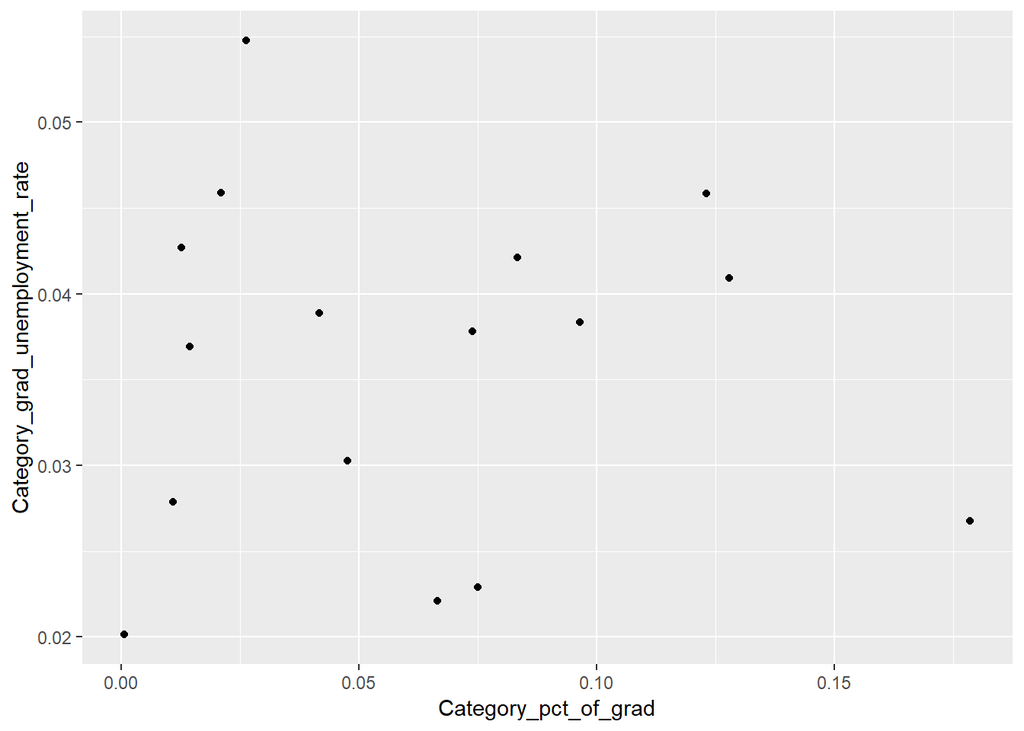

```r
ggplot(category_subtotals, aes(x = Category_pct_of_grad, y = Category_grad_unemployment_rate)) +
  geom_point()
```

6. Add color to data points by major_category

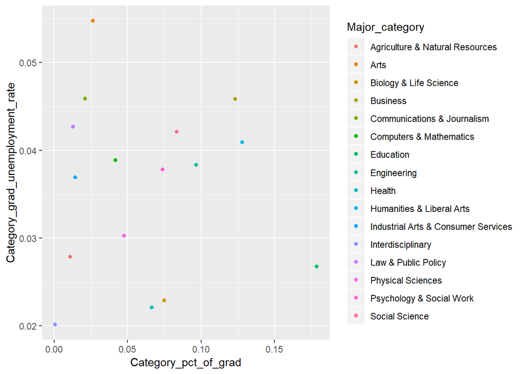

```r
ggplot(category_subtotals, aes(x = Category_pct_of_grad, y = Category_grad_unemployment_rate)) +
  geom_point(aes(color = Major_category))
```

7. Add size to data based on count of major_category

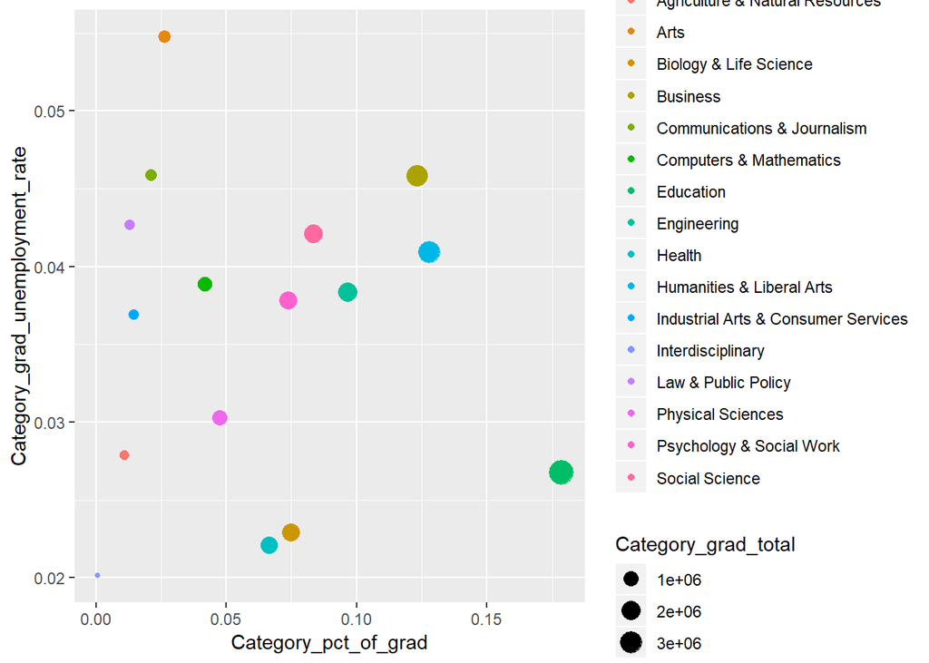

```r
ggplot(category_subtotals, aes(x = Category_pct_of_grad, y = Category_grad_unemployment_rate)) +
  geom_point(aes(color = Major_category, size = Category_grad_total))
```

8. Add linear regression line, suppressing confidence regions

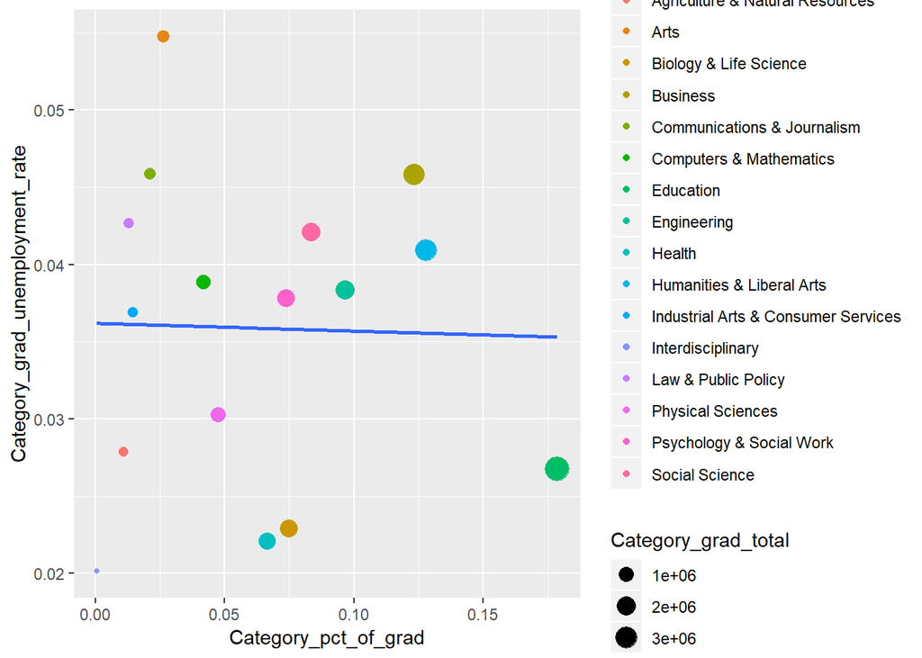

```r
ggplot(category_subtotals, aes(x = Category_pct_of_grad, y = Category_grad_unemployment_rate)) +
  geom_point(aes(color = Major_category, size = Category_grad_total)) +
  geom_smooth(method=lm, se=FALSE)
```

## Conclusions

There does not appear to be any meaningful correlation between a major’s general job prospects and the rate at which students choose a major.